# 🎰 05 Projection Engine

| Title | 05 Projection Engine |
| --- | --- |
| Case Study | Climate-Adjusted Mortality for Selected EU Countries |
| Research Project | CC230 Quantifying Mortality and Morbidity Impacts from Climate Risks |
| Notebook | `05_projection_engine.ipynb` |
| Author | Carlos Arocha, FSA, SCR |
| Sponsor | Catastrophe and Climate Strategic Research Program, Society of Actuaries Research Institute |
| Date | `2026-05-11` |
| Version | `v1.0.0` |
| Questions? | Questions regarding this notebook should be directed to the SOA project contact |

## Purpose

- the baseline Lee-Carter parameters from Notebook 03;
- the calibrated climate-sensitivity parameter $\lambda_{x,r}$ from Notebook 04; and
- the projected composite climate index $C_{t,r}$ from Notebook 02.

The projection model is:

$\log m_{x,t,r}^{\text{climate-adjusted}}=a_{x,r}+b_x k_t^{\text{proj}}+\lambda_{x,r} C_{t,r}^{\text{proj}}$

For comparison, the no-climate baseline projection is:

$\log m_{x,t,r}^{\text{baseline}}=a_{x,r}+b_x k_t^{\text{proj}}$

The climate component is therefore:

$\Delta \log m_{x,t,r}=\lambda_{x,r} C_{t,r}^{\text{proj}}$

For this case-study implementation, $\lambda_{x,r}$ is floored at zero when used in projection. This avoids interpreting a positive heat-related climate index as reducing projected mortality. This is a modeling choice and should be reviewed as part of sensitivity testing and model governance.

- `Toolkit/outputs/baseline_parameters_a_xr_2004_2025_excl_2020_2021.csv`
- `Toolkit/outputs/baseline_parameters_b_x_2004_2025_excl_2020_2021.csv`
- `Toolkit/outputs/baseline_parameters_k_t_2004_2025_excl_2020_2021.csv`
- `Toolkit/outputs/climate_parameters_lambda_xr_2004_2025_excl_2020_2021.csv`
- `Toolkit/data/processed/climate/C_tr_core_country_annual_combined_era5_cmip6_{SCENARIO}.csv`

## Outputs

- `Toolkit/outputs/projected_k_t_{PROJECTION_YEARS}.csv`
- `Toolkit/outputs/projected_mortality_baseline_and_climate_adjusted_{PROJECTION_YEARS}.csv`
- `Toolkit/outputs/projected_mortality_impact_summary_{PROJECTION_YEARS}.csv`
- `Toolkit/outputs/projected_mortality_by_country_year_{PROJECTION_YEARS}.csv`

Report:

- `CC230 Toolkit/reports/{NOTEBOOK}.html`

## Dependencies

This notebook can be run in Google Colab or any compatible Jupyter environment, such as:

- JupyterLab
- Jupyter Notebook
- VS Code with the Jupyter extension
- Anaconda Navigator
- Kaggle Notebooks

The notebook was developed using:

- Python 3.14.5
- Required libraries installed through the setup cell below

## Disclaimer

The Jupyter notebooks available through this repository are provided for research, educational, and illustrative purposes only. They are not intended to constitute actuarial advice or to represent production-ready systems without further validation, customization, and governance by the user.

While reasonable efforts have been made to ensure accuracy and consistency, no guarantee is given as to completeness, fitness for a particular purpose, or compliance with applicable actuarial standards or regulatory requirements.

Users are responsible for assessing the suitability of the materials for their specific use cases and for implementing appropriate controls, validation, and documentation prior to any operational use.

## License

© 2026 Society of Actuaries. Except where otherwise noted, the textual content of this book is licensed under the Creative Commons Attribution–Noncommercial–Share Alike 4.0 International License (CC BY-NC-SA 4.0). Source code samples, including scripts, notebooks, and code blocks where indicated, are licensed under the MIT License, unless otherwise stated.

## Setup and Shared Configuration

```
Loaded control files:
 - run_config.json
 - input_manifest.csv
 - 02_climate_features_output_manifest.csv
 - 03_baseline_mortality_model_output_manifest.csv
 - 04_climate_calibration_output_manifest.csv
```

## Settings derived from Notebook 01

All case-study settings are read from `run_config.json`. This keeps scenario, calibration years, projection years, country list, and age range consistent across the notebook suite.

```
{
  "notebook": "05_projection_engine.ipynb",
  "run_timestamp_utc": "2026-07-21T07:10:28.081838+00:00",
  "project_root": "C:\\Users\\ca\\OneDrive\\Documents\\@ PROJECTS\\CC230-Toolkit",
  "scenario": "ssp5_8_5",
  "countries": [
    "ES",
    "FR",
    "IT"
  ],
  "calibration_years": [
    2004,
    2005,
    2006,
    2007,
    2008,
    2009,
    2010,
    2011,
    2012,
    2013,
    2014,
    2015,
    2016,
    2017,
    2018,
    2019,
    2022,
    2023,
    2024,
    2025
  ],
  "excluded_calibration_years": [
    2020,
    2021
  ],
  "projection_start_year": 2030,
  "projection_end_year": 2060,
  "age_min": 20,
  "age_max": 85,
  "k_projection_method": "linear_extrapolation_selected_calibration_years",
  "lambda_projection_treatment": "lambda_xr is filled for missing values and floored at zero before projection"
}
```

## Helper Functions and Input Checks

The helper functions below retrieve input files from the upstream manifests, validate required columns, and register Notebook 05 outputs for downstream use.

```
Required Notebook 5 input files:
 - a_xr: baseline_parameters_a_xr_2004_2025_excl_2020_2021_age20_85.csv
 - b_x: baseline_parameters_b_x_2004_2025_excl_2020_2021_age20_85.csv
 - k_t: baseline_parameters_k_t_2004_2025_excl_2020_2021_age20_85.csv
 - lambda_xr: climate_parameters_lambda_xr_2004_2025_excl_2020_2021_age20_85.csv
 - C_tr: C_tr_core_country_annual_cmip6_ssp5_8_5_2030_2060.csv
```

## Load Baseline Lee-Carter Parameters

The baseline parameters $a_{x,r}$, $b_x$, and $k_t$ are produced by Notebook 03. The time index $k_t$ is then projected from the selected calibration years.

```
a_xr rows: 198
b_x rows: 66
k_t years: 2004 to 2025
```

## Load and Prepare $\lambda_{x,r}$

The calibrated $\lambda_{x,r}$ parameter is read from Notebook 04. In this implementation, the same `lambda_xr` column is used in projection after replacing missing values with zero and flooring negative values at zero.

```
lambda_xr rows: 198
Missing lambda values set to zero: 0
```

## Load Projected $C_{t,r}$

The climate index is read from Notebook 02. Projection rows are selected using the scenario and projection years defined in Notebook 01.

```
Using climate index column: C_tr_core
Available projection scenarios: ['ssp5_8_5']
Projected climate rows: 93
Projection years: 2030 to 2060
```

## Project $k_t$

The default projection method is a linear extrapolation fitted to the selected calibration years.

```
k_t successfully projected
```

## Build Projection Panel

The projection grid joins the baseline age-country parameters, the projected time index, the floored climate-sensitivity parameter, and projected climate index.

```
Projection panel rows: 6138
Expected rows if all countries, ages, and years are present: 6138
Countries: ['ES', 'FR', 'IT']
Years: 2030 to 2060
```

## Project Mortality Rates

This section computes baseline projected mortality, climate-adjusted projected mortality, and the absolute and relative climate impacts.

```
Maximum implementation error: 8.881784197001252e-16
```

## Projection Summaries

Aggregate the projected impact by age-country and by country-year.

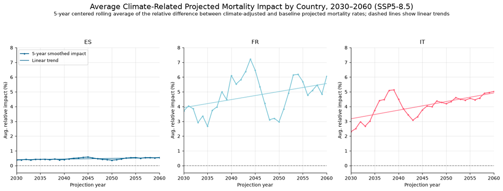

|  | country | age_band | avg_relative_impact_pct | median_relative_impact_pct | min_relative_impact_pct | max_relative_impact_pct | n_observations | n_ages | n_years |
| --- | --- | --- | --- | --- | --- | --- | --- | --- | --- |
| 0 | ES | 20–44 | 0.579986 | 0.000000 | 0.000000 | 11.784379 | 775 | 25 | 31 |
| 1 | ES | 45–64 | 0.394464 | 0.000000 | 0.000000 | 3.592892 | 620 | 20 | 31 |
| 2 | ES | 65–85 | 0.397296 | 0.000000 | 0.000000 | 6.278115 | 651 | 21 | 31 |
| 3 | FR | 20–44 | 8.662499 | 7.694338 | -3.292972 | 36.560427 | 775 | 25 | 31 |
| 4 | FR | 45–64 | 0.829580 | 0.000000 | -1.102327 | 10.865785 | 620 | 20 | 31 |
| 5 | FR | 65–85 | 3.987184 | 3.064069 | -1.691446 | 17.204412 | 651 | 21 | 31 |
| 6 | IT | 20–44 | 5.243697 | 2.514350 | 0.000000 | 35.415930 | 775 | 25 | 31 |
| 7 | IT | 45–64 | 4.205705 | 0.000000 | 0.000000 | 26.807445 | 620 | 20 | 31 |
| 8 | IT | 65–85 | 2.517005 | 0.271734 | 0.000000 | 13.658990 | 651 | 21 | 31 |

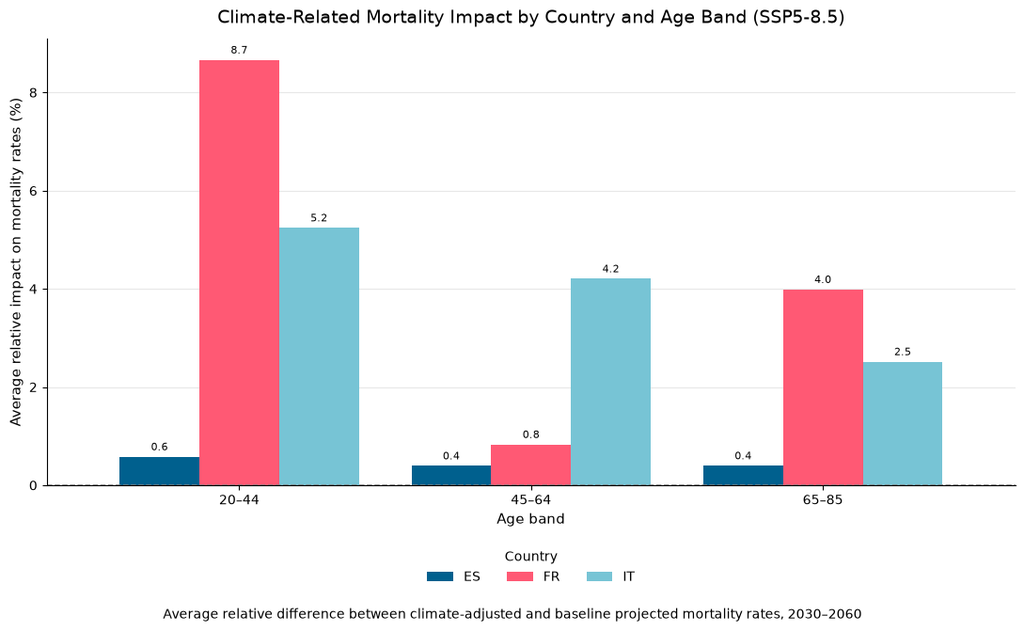

| Period | country | 2030-2060 | 2040-2060 | 2050-2060 |
| --- | --- | --- | --- | --- |
| 0 | ES | 0.47 | 0.49 | 0.50 |
| 1 | FR | 4.80 | 5.22 | 5.40 |
| 2 | IT | 4.06 | 4.22 | 4.68 |

| period country age_band | 2030-2060 ES | 2030-2060 FR | 2030-2060 IT | 2040-2060 ES | 2040-2060 FR | 2040-2060 IT | 2050-2060 ES | 2050-2060 FR | 2050-2060 IT |
| --- | --- | --- | --- | --- | --- | --- | --- | --- | --- |
| 20-44 | 0.58 | 8.66 | 5.24 | 0.61 | 9.42 | 5.45 | 0.63 | 9.75 | 6.04 |
| 45-64 | 0.39 | 0.83 | 4.21 | 0.42 | 0.90 | 4.37 | 0.43 | 0.93 | 4.85 |
| 65-85 | 0.40 | 3.99 | 2.52 | 0.42 | 4.33 | 2.62 | 0.43 | 4.48 | 2.90 |

## Diagnostic Plots

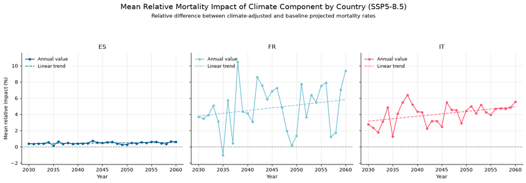

## Save Outputs

The projection panel and summary files are saved to the output folder. A Notebook 05 output manifest is also written for Notebook 06.

```
Saved projection outputs:
  - projected_k_t_2004_2025_excl_2020_2021_2030_2060.csv
  - projected_mortality_baseline_and_climate_adjusted_ssp5_8_5_2030_2060_age20_85.csv
  - projected_mortality_impact_summary_ssp5_8_5_2030_2060_age20_85.csv
  - projected_mortality_by_country_year_ssp5_8_5_2030_2060_age20_85.csv
```

## Output Manifest

This final cell writes the Notebook 05 output manifest. Downstream notebooks should read this manifest rather than reconstructing file names manually.

```
Saved Notebook 5 output manifest:
05_projection_engine_output_manifest.csv
0    projected_k_t_2004_2025_excl_2020_2021_2030_20...
1    projected_mortality_baseline_and_climate_adjus...
2    projected_mortality_impact_summary_ssp5_8_5_20...
3    projected_mortality_by_country_year_ssp5_8_5_2...
Name: file_name, dtype: str

==============================================================================
✅ NOTEBOOK 5 COMPLETE
==============================================================================
Please review the projection output files, diagnostic plots, and output manifest listed above.
Next step: run Notebook 6 — 06_sensitivity_and_validation.ipynb
==============================================================================
```